# GoBike Project: Data Visualization

## by Karlheinz Huscher Cirne

## Investigation Overview

> The visual analysis of the dataframe will focus in analyze and provide insights to 3 questions :
> - What is the average duration of bike rides?
> - Does people prefer to ride bikes in some specific months?
> - Is there a difference in the duration of bike rides from subscribers or a customers?

## Dataset Overview

> This project was created to analyze the Ford GoBike Dataset from Bay Wheels to extract insights and behaviours about individual bike rides made in a bike-sharing system covering the greater San Francisco Bay area.

## What is the average duration of bike rides?

> To answer this question, a bar chat was plotted to analyze the distribution of bike rides according to duration.

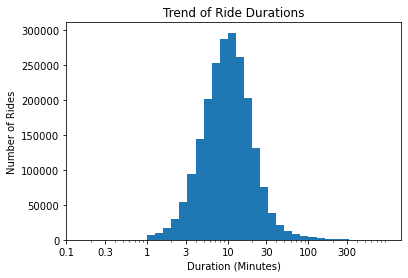

```python
# Plotting ride duration count on log scale

bin_edges = 10**np.arange(0, 3+0.1, 0.1)
x_ticks =  [ 0.1, 0.3, 1, 3, 10, 30, 100, 300]
x_labels = ['{}'.format(v) for v in x_ticks]
plt.hist(data = df_bike, x = 'duration_min', bins = bin_edges);
plt.xscale('log');
plt.xticks(x_ticks,x_labels);
plt.title('Trend of Ride Durations')
plt.xlabel('Duration (Minutes)');
plt.ylabel('Number of Rides');
```

#### Conclusion Visualization 1

> It is possible to observe that most people take bike rides from 5 to 20 minutes.

## Does people prefer to ride bikes in some specific months?

> A scatter plot makes it easier to analyze a behaviour from 2 variables. A comparison of Months versus Duration in minutes is performed. Some transparency was added in order to verify the periods with more bike rides.

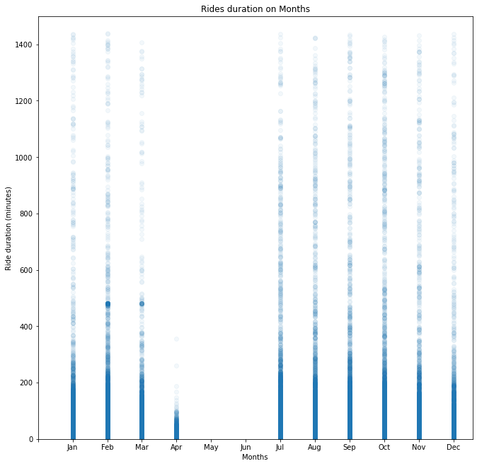

```python
plt.figure(figsize = [11,11])
x_ticks = np.arange(0, 13, 1)
x_ticks_names = ["", "Jan","Feb", "Mar", "Apr", "May", "Jun", "Jul", "Aug", "Sep", "Oct", "Nov", "Dec", ""]
plt.scatter(data = df_bike, x = 'start_month' , y = 'duration_min' , alpha = 0.05 )
plt.ylim(0,1500)
plt.title('Rides duration on Months')
plt.xticks(x_ticks, x_ticks_names)
plt.xlabel('Months')
plt.ylabel('Ride duration (minutes)');
```

## Is there a difference in the duration of bike rides from subscribers or a customers?

> As a final analysis, number of bike rides versus months versus user type will be analyzed. To perform this task, the FacetGrid function from seaborn will be used.

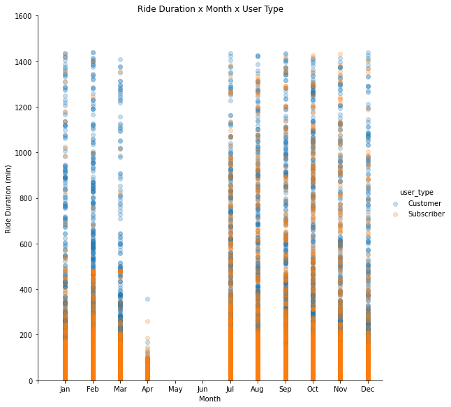

```python
x_ticks = np.arange(0, 13, 1)
x_ticks_names = ["", "Jan","Feb", "Mar", "Apr", "May", "Jun", "Jul", "Aug", "Sep", "Oct", "Nov", "Dec", ""]
g = sb.FacetGrid(data =  df_bike, hue = 'user_type', height = 8)
g.map(plt.scatter, 'start_month','duration_min', alpha = 1/4)
g.add_legend()
plt.ylim(0,1600)
plt.xticks(x_ticks, x_ticks_names)
plt.title('Ride Duration x Month x User Type')
plt.xlabel('Month')
plt.ylabel('Ride Duration (min)');
```